# Lecture Notes 3

# Simple Linear Regression with a qualitative regressor

## Summary

*Simple linear regression with a qualitative regressor* is used to model the **mean** of a quantitative random variable as a linear function of another *qualitative* random variable

## True model

- For two quantitative random variables $X$ and $Y$, a simple linear model is  
  $E(Y) = \beta_0 + \beta_1 X$  
  where $\beta_0$ and $\beta_1$ are unknown, true model parameters (or coefficients), and $\beta_1$ is called the regression coefficient.
- The above model is equivalent to  
  $Y = \beta_0 + \beta_1 X + \epsilon$ with $E(\epsilon) = 0$  
  which is called the population regression line

# Linear regression with a qualitative regressor

## Motivation

- How is the `Balance` of a credit card related to its holder’s `Gender`?
- How is the `Balance` of a credit card related to its holder’s `Ethnicity`?

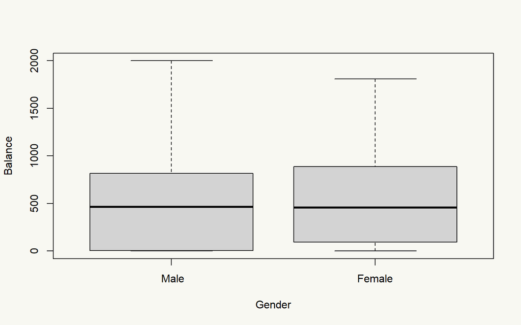

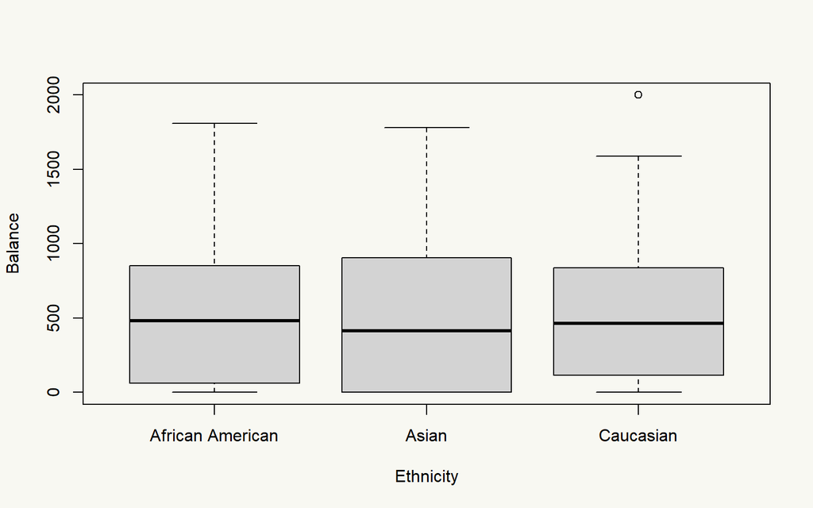

```r
par(bg = "#f8f8f2")
boxplot(Balance ~ Gender, data = Credit)
boxplot(Balance ~ Ethnicity, data = Credit)
```

## Model 1: 2 levels

### Fitting the Model 1

```r
lm(formula = Balance ~ Gender, data = Credit)
```

```
##
## Call:
## lm(formula = Balance ~ Gender, data = Credit)
##
## Coefficients:
##  (Intercept)  GenderFemale
##       509.80         19.73
```

- `Male` card holders have a `Balance` of $\$509.80$
- `Female` card holders have a `Balance` of $(\$509.80 + \$19.73) = \$529.53$

### Testing the Model 1

```r
lm(formula = Balance ~ Gender, data = Credit)
##
## Call:
## lm(formula = Balance ~ Gender, data = Credit)
##
## Coefficients:
##  (Intercept)  GenderFemale
##       509.80         19.73
summary(lm(formula = Balance ~ Gender, data = Credit))
##
## Call:
## lm(formula = Balance ~ Gender, data = Credit)
##
## Residuals:
##     Min      1Q  Median      3Q     Max
## -529.54 -455.35  -60.17  334.71 1489.20
##
## Coefficients:
##              Estimate Std. Error t value Pr(>|t|)
## (Intercept)    509.80      33.13  15.389   <2e-16 ***
## GenderFemale    19.73      46.05   0.429    0.669
## ---
## Signif. codes:  0 '***' 0.001 '**' 0.01 '*' 0.05 '.' 0.1 ' ' 1
##
## Residual standard error: 460.2 on 398 degrees of freedom
## Multiple R-squared:  0.0004611,  Adjusted R-squared:  -0.00205
## F-statistic: 0.1836 on 1 and 398 DF,  p-value: 0.6685
```

- If model assumptions are met, `Gender` is not significant on affecting average `Balance` at 5% significance level based on the F-Statistic

## Model 2: 3 levels

- `Ethnicity` has 3 levels, `African American`, `Asian`, and `Caucasian`. *2 dummy variables are needed*
  - $x_{i, 1} = 0$ if the $i\text{th}$ person is *not* `Asian` and $x_{i, 1} = 1$ if $i\text{th}$ person is `Asian`
  - $x_{i, 2} = 0$ if the $i\text{th}$ person is *not* `Caucasian` and $x_{i, 2} = 1$ if $i\text{th}$ person is `Caucasian`
- Model:

  $y_i = \beta_0 + \beta_1 x_{i, 1} + \beta_2 x_{i, 2} + \epsilon_i$
- Codings on previous slide
- $\beta_0$: average `Balance` of `African American` card holders
- $\beta_1$: average difference in `Balance` between `Asian` and `African American` card holders
- $\beta_2$: average difference in `Balance` between `Caucasian` and `African American` card holders

### Fitting the Model 2

```r
lm(formula = Balance ~ Ethnicity, data = Credit)
##
## Call:
## lm(formula = Balance ~ Ethnicity, data = Credit)
##
## Coefficients:
##        (Intercept)      EthnicityAsian  EthnicityCaucasian
##             531.00              -18.69              -12.50
```

- `African American` card holders have an average balance of $\$531$
- `Asian` card holders have an average balance of $\$(531 - 18.69) = \$512.31$
- `Caucasian` card holders have an average balance of $\$(531 - 12.50) = \$518.50$

### Testing the Model 2

```r
lm(formula = Balance ~ Ethnicity, data = Credit)
```

```
##
## Call:
## lm(formula = Balance ~ Ethnicity, data = Credit)
##
## Coefficients:
##        (Intercept)      EthnicityAsian  EthnicityCaucasian
##             531.00              -18.69              -12.50
```

```r
summary(lm(formula = Balance ~ Ethnicity, data = Credit))
```

```
##
## Call:
## lm(formula = Balance ~ Ethnicity, data = Credit)
##
## Residuals:
##     Min      1Q  Median      3Q     Max
## -531.00 -457.08  -63.25  339.25 1480.50
##
## Coefficients:
##                    Estimate Std. Error t value Pr(>|t|)
## (Intercept)          531.00      46.32  11.464   <2e-16 ***
## EthnicityAsian       -18.69      65.02  -0.287    0.774
## EthnicityCaucasian   -12.50      56.68  -0.221    0.826
## ---
## Signif. codes:  0 '***' 0.001 '**' 0.01 '*' 0.05 '.' 0.1 ' ' 1
##
## Residual standard error: 460.9 on 397 degrees of freedom
## Multiple R-squared:  0.0002188,  Adjusted R-squared:  -0.004818
## F-statistic: 0.04344 on 2 and 397 DF,  p-value: 0.9575
```

- If model assumptions are met, at 5% significance level, `Ethnicity` does not significantly affect average `Balance` based on the F-Statistic

```r
tidy(lm(formula = Balance ~ Ethnicity, data = Credit))
## # A tibble: 3 × 5
##   term               estimate std.error statistic  p.value
##   <chr>                 <dbl>     <dbl>     <dbl>    <dbl>
## 1 (Intercept)           531        46.3    11.5   1.77e-26
## 2 EthnicityAsian        -18.7      65.0    -0.287 7.74e- 1
## 3 EthnicityCaucasian    -12.5      56.7    -0.221 8.26e- 1
```

- If model assumptions are met and `Ethnicity` does not significantly affect average `Balance`, there is no need to check:
  - whether there is a significant difference in average `Balance` between `Asian` and `African American` card holders or between `Caucasian` and `African American` card holders

# Diagnostics

- Diagnostics are the same as those for simple linear regression with a quantitative predictor

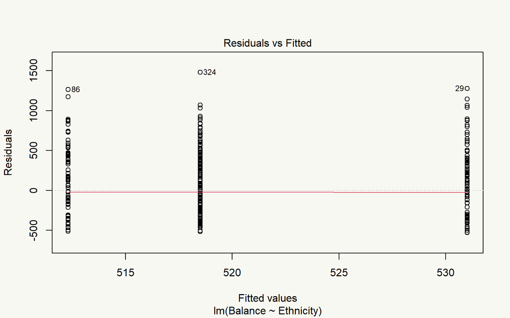

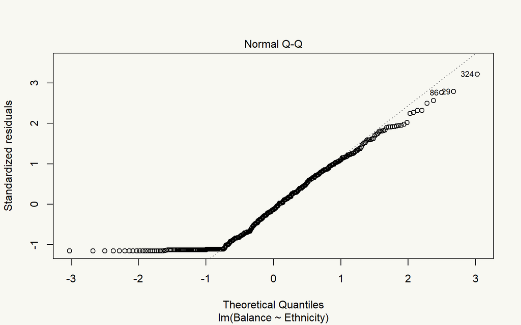

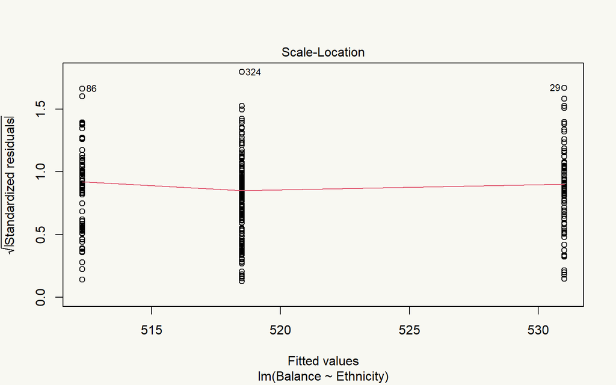

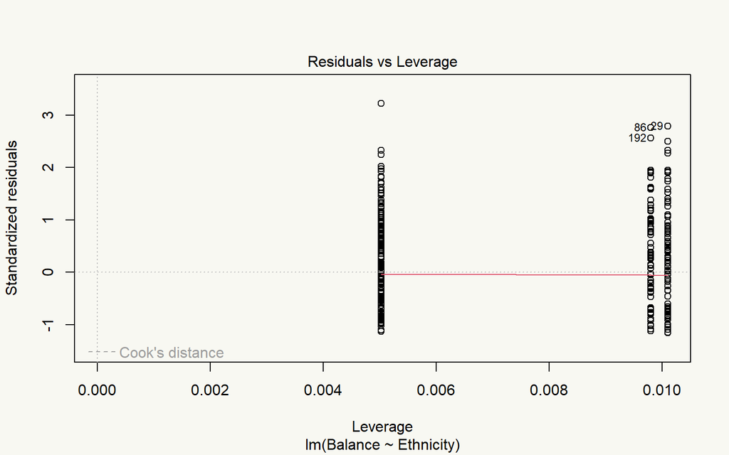

```r
par(bg = "#f8f8f2")
plot(lm(Balance ~ Ethnicity, data = Credit)) # I only had to use this to generate all 4 plots
```

# Multiple Linear Regression

## Motivation

- How is `sales` (in thousands of units) for a particular product related to advertising budgets (in thousands of dollars) for `TV`, `Radio`, and `Newspaper`?
- Model:

  $\text{sales} = \beta_0 + \beta_1 \text{TV} + \beta_2 \text{Radio} + \beta_3 \text{Newspaper} + \epsilon$
- We want to examine the relationship between `sales` and budgets for `TV`, `Radio`, and `Newspaper` *jointly* instead of *marginally*

## Model

- Response $Y$ and $p$ predictors $X_1, X_2, \dots, X_p$ are bound by the model:

  $Y = \beta_0 + \beta_1 X_1 + \beta_2 X_2 + \dots + \beta_p X_p + \epsilon$
- $\beta_j$ change in units in $E(Y)$ for a unit change in $X_j$ with all other predictors held constant
- $\epsilon$: error term with $E(\epsilon) = 0$ and $Var(\epsilon) = \sigma^2$
- Estimate coefficient vector $\beta = (\beta_0, \beta_1, \dots, \beta_p)$ by the *least squares method*; estimate $\hat{\beta} = (\hat{\beta}_0, \hat{\beta}_1, \dots, \hat{\beta}_p)$ as *LSE* (least squares estimator)

## Fitting the Model

- Joint model vs marginal model

## Testing on all coefficients

- Is there a relationship between the response and any of the predictors? Namely, is $H_0: \beta_1 = \beta_2 = \dots = \beta_p = 0$ true?
- Test statistic: F-Statistic

  $F = \frac{(TSS - RSS)/p}{RSS/(n - p - 1)}$  
  Where $TSS = \sum_{i = 1}^n (y_i - \bar{y})^2$ and $RSS = \sum_{i = 1}^n (y_i - \hat{y}_i)^2$
- If $H_0$ is true and the linear model assumptions are correct, F-statistic should be close to 1 on average; undersuitable conditions, the F-statistic approiximately follows an F-distribution
- When $H_0$ and model assumptions are true, test statistic

  $F = \frac{(RSS_0 - RSS)/q}{RSS/(n - p - 1)}$  
  Where $RSS_0 = \sum_{i = 1}^n (y_i - \bar{y})^2$

  approximately follows an F-distribution with $q$ and $n - p - 1$ degrees of freedom

## Testing on model fit

- $R^2$ measures the proportion of variance in the response that is explained by the model
- With 3 predictors:

```r
Advertising <- read.csv("Advertising.csv")
FitL3c <- lm(sales ~ TV + radio + newspaper, data = Advertising)
summary(FitL3c)$r.squared
## [1] 0.8972106
```

- With 1 predictor:

```r
FitL1c <- lm(sales ~ newspaper, data = Advertising)
summary(FitL1c)$r.squared
## [1] 0.05212045
```

# Interaction Terms: I

- If change (in unit) in $E(\text{sales})$ can be different for a unit change in `TV` at different values of `Radio` of for a unit change in `Radio` at different values of `TV`, then the model

  $E(\text{sales}) = \beta_0 + \beta_1 \text{TV} + \beta_2 \text{Radio}$

  is no longer suitable
- One way to account for this is to introduce an **interaction term** and use the model:

  $E(\text{sales}) = \beta_0 + \beta_1 \text{TV} + \beta_2 \text{Radio} + \beta_3 \text{TV} \times \text{Radio}$
- A model like this:

  $E(\text{sales}) = \beta_0 + \beta_1 \text{TV} + \beta_2 \text{Radio} + \beta_3 \text{TV}^2 + \beta_4 \text{Radio}^2$

  would not work because there is no math to take into account the interaction between `TV` and `Radio`
- The model

  $E(\text{sales}) = \beta_0 + \beta_1 \text{TV} + \beta_2 \text{Radio} + \beta_3 \text{TV} \times \text{Radio}$

  can be written as

  $E(\text{sales}) = \beta_0 + \beta_1 \times \text{TV} + (\beta_2 + \beta_3 \times \text{TV}) \times \text{Radio}$

  or

  $E(\text{sales}) = \beta_0 + (\beta_1 + \beta_3 \times \text{Radio}) \times \text{TV} + \beta_2 \times \text{Radio}$

# Bootstrap

- The **bootstrap** is mainly used to estimate and quantify the uncertainty associated with a given estimate or statisticl learning method
- For example, it can be used to estimate the standard error of an estimate (such as an estimated coefficient in a regression model)
- The bootstrap may not work well when sample size is small

# Illustration 1

## problem

Problem formulation:

- suppose we wish to invest a fixed sum of money into two financial assets that yield (random) returns of $X$ and $Y$
- We will invest a fraction $\alpha$ of our money in $X$ and the rest $1-\alpha$ in $Y$
- We ned to choose $\alpha$ to minimize the risk of our investment

Namely, we need to find $\alpha$ that minimizes
$$\text{Var}(\alpha X + (1 -
\alpha)Y)$$
$$\neq \alpha^2 \text{Var}(X) + (1 -
\alpha)^2 \text{Var}(Y)$$
unless it’s the case that $\text{Cov}(X, Y) = 0$

## solution

- By calculus , we know that
  $$\alpha = \frac{\sigma_Y^2 -
  \sigma_{XY}}{\sigma_X^2 + \sigma_Y^2 - 2\sigma_{XY}}$$
  minimizes
  $$\text{Var}(\alpha X + (1 -
  \alpha)Y)$$
  where $\sigma_X^2 = \text{Var}(X)$, $\sigma_Y^2 = \text{Var}(Y)$, and $\sigma_{XY} = \text{Cov}(X, Y)$
- However, in reality, the quantities $\sigma_X^2$, $\sigma_Y^2$, and $\sigma_{XY}$ are unknown and need to be estimated

## Estimate

- With estimates $\hat{\sigma}_X^2$, $\hat{\sigma}_Y^2$, and $\hat{\sigma}_{XY}$, we have the plug-in estimate
  $$\hat{\alpha} = \frac{\hat{\sigma}_Y^2 -
  \hat{\sigma}_{XY}}{\hat{\sigma}_X^2 + \hat{\sigma}_Y^2 -
  2\hat{\sigma}_{XY}}$$
- If $\hat{\sigma}_X^2$, $\hat{\sigma}_Y^2$, and $\hat{\sigma}_{XY}$ are accurate, then $\hat{\alpha}$ is a good estimate of $\alpha$
- How do we assess the accuracy of $\hat{\alpha}$ if we only have a sample of size $n$ at hand?
  - Speed of convergence

## Simulated samples

- If we know the population distribution, we can simulate samples
- Suppose we simulate $B = 1000$ *independent samples* for $(X, Y)$ (if we knew the truth), we will have $B$ estimates $\hat{\alpha}_j, j = 1, \dots, B$ of $\alpha$
- The sample mean $\bar{\alpha} = \frac{1}{B} \sum_{j = 1}^B \hat{\alpha}_j$ should be close to $\alpha$
- The sample standard deviation
  $$s(\hat{\alpha}) = \sqrt{\frac{1}{B - 1}
  \sum_{j = 1}^B (\hat{\alpha}_j - \bar{\alpha})^2}$$
  (of s) should be close to $\sigma_{\hat{\alpha}} = \sqrt{\text{Var}(\hat{\alpha})}$

# Info about the 10/21 quiz

- you will be asked to load a library `library(lib_name)`
- load dataset `data(dataset)`
- fit simple linear regression model with 1 predictor `lm(y ~ x, data = dataset)`
- Produce summary `summary(lm(y ~ x, data = dataset))`
- Produce diagnostic plots `plot(lm(Balance ~ Ethnicity, data = Credit)) #example from earlier`
- load another dataset
- fit a multiple linear regression model with 1 response and some predictors
- Produce summary